# How to run your analysis parallelly

As we approach the exascale barrier, researchers are handling increasingly large volumes of molecular dynamics (MD) data. Whilst MDAnalysis is a flexible and relatively fast framework for complex analysis tasks in MD simulations, implementing a parallel computing framework would play a pivotal role in accelerating the time to solution for such large datasets.

This document illustrates how you can run your own analysis scripts parallelly with MDAnalysis.

**Last executed:** Aug 13, 2020 with MDAnalysis 2.0.0

**Last updated:** Augus 2020

**Minimum version of MDAnalysis:** 2.0.0

**Packages required:**

- MDAnalysis ([MADWB11], [GLB+16])
- MDAnalysisTests

```python
import MDAnalysis as mda
from MDAnalysis.tests.datafiles import PSF, DCD

import numpy as np
import pandas as pd
import matplotlib.pyplot as plt
%matplotlib inline
```

```python
import multiprocessing
from multiprocessing import Pool
from multiprocessing import cpu_count
from functools import partial

import dask
```

## Radius of gyration

For detail description of this analysis, read Writing your own trajectory.

Here is a common form of single-frame method that we can normally see inside `AnalysisBase`. It may contain both some dynamic parts that changes along time either implicitly or explicitly (e.g. `AtomGroup`) and some static parts (e.g. a reference frame).

```python
def radgyr_old(atomgroup, masses, total_mass=None):
    # coordinates change for each frame
    coordinates = atomgroup.positions
    center_of_mass = atomgroup.center_of_mass()

    # get squared distance from center
    ri_sq = (coordinates-center_of_mass)**2
    # sum the unweighted positions
    sq = np.sum(ri_sq, axis=1)
    sq_x = np.sum(ri_sq[:,[1,2]], axis=1) # sum over y and z
    sq_y = np.sum(ri_sq[:,[0,2]], axis=1) # sum over x and z
    sq_z = np.sum(ri_sq[:,[0,1]], axis=1) # sum over x and y

    # make into array
    sq_rs = np.array([sq, sq_x, sq_y, sq_z])

    # weight positions
    rog_sq = np.sum(masses*sq_rs, axis=1)/total_mass
    # square root and return
    return np.sqrt(rog_sq)
```

## Transform into parallel-compatible form

First, we need to modify the single-frame method to contain the `frame_index`. Then we explicitly point to the frame need to be analyzed:

`atomgroup.universe.trajectory[frame_index]`

```python
def radgyr(frame_index, atomgroup, masses, total_mass=None):
    atomgroup.universe.trajectory[frame_index]
    # coordinates change for each frame
    coordinates = atomgroup.positions
    center_of_mass = atomgroup.center_of_mass()

    # get squared distance from center
    ri_sq = (coordinates-center_of_mass)**2
    # sum the unweighted positions
    sq = np.sum(ri_sq, axis=1)
    sq_x = np.sum(ri_sq[:,[1,2]], axis=1) # sum over y and z
    sq_y = np.sum(ri_sq[:,[0,2]], axis=1) # sum over x and z
    sq_z = np.sum(ri_sq[:,[0,1]], axis=1) # sum over x and y

    # make into array
    sq_rs = np.array([sq, sq_x, sq_y, sq_z])

    # weight positions
    rog_sq = np.sum(masses*sq_rs, axis=1)/total_mass
    # square root and return
    return np.sqrt(rog_sq)
```

## Loading files

The test files we will be working with here feature adenylate kinase (AdK), a phosophotransferase enzyme. ([BDPW09])

```python
u = mda.Universe(PSF, DCD)
protein = u.select_atoms('protein')
```

## Create a pool of workers with multiprocess

The native parallel module in python is called `multiprocessing`, it contains some useful tools to build a pool of working cores, map the function into different workers, and gather and order the results from all the workers.

Below we use `Pool` from `multiprocessing` as a context manager, we can define how many cores (or workers) we want tu use. By `Pool(n_jobs)`. Then we can map our analysis method `radgyr` with the parameters needed with `partial`. Note we do not include `frame_index` inside partial, because `frame_index` is the variable that is iterated to create a list of jobs.

The serialized version is:

```python
result = []
for frame_index in range(u.trajectory.n_frames):
    result.append(radgyr(frame_index,
                         atomgroup=protein,
                         masses=protein.masses,
                         total_mass=np.sum(protein.masses))
```

```python
n_jobs = cpu_count()
with Pool(n_jobs) as worker_pool:
    result = worker_pool.map(partial(radgyr,
                                     atomgroup=protein,
                                     masses=protein.masses,
                                     total_mass=np.sum(protein.masses)),
                             range(u.trajectory.n_frames))
```

The `result` will be a list of arrays containing the result for each frame. Finally the results can be plotted along time.

```python
result = np.asarray(result).T

labels = ['all', 'x-axis', 'y-axis', 'z-axis']
for col, label in zip(result, labels):
    plt.plot(col, label=label)
plt.legend()
plt.ylabel('Radius of gyration (Å)')
plt.xlabel('Frame');
```

[figure not shown]

## Create a pool of workers with Dask

Dask is the parallel module that is used inside PMDA. It can be scaled from one single computer to a cluster of computers inside a HPC center.

Below is a simple example to use Dask to achieve the same task as `multiprocess` does.

The API of Dask is similiar to `multiprocess`. It also creates a pool of workers with the given resources.

```python
from dask.distributed import Client

client = Client(n_workers=12)
client
```

Client

- **Scheduler:** tcp://127.0.0.1:33497

- **Dashboard:** http://127.0.0.1:8787/status

Cluster

- **Workers:** 12

- **Cores:** 12

- **Memory:** 16.49 GB

First we have to create a list of jobs and transform them with `dask.delayed()` so they can be processed by Dask.

```python
job_list = []
for frame_index in range(u.trajectory.n_frames):
    job_list.append(dask.delayed(radgyr(frame_index,
                                        atomgroup=protein,
                                        masses=protein.masses,
                                        total_mass=np.sum(protein.masses))))
```

Then we simply use `dask.compute()` to get a list of ordered results.

```python
result = dask.compute(job_list)
```

```python
result = np.asarray(result).T

labels = ['all', 'x-axis', 'y-axis', 'z-axis']
for col, label in zip(result, labels):
    plt.plot(col, label=label)
plt.legend()
plt.ylabel('Radius of gyration (Å)')
plt.xlabel('Frame');
```

[figure not shown]

We can also use Dask dashboard to examine how jobs are distributed along all the workers. So each green bar below reprsents a single-frame `radgyr`.

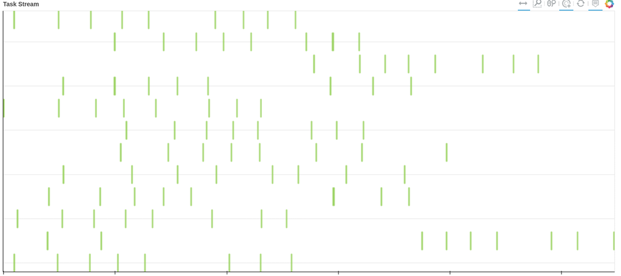

## References

[1] Oliver Beckstein, Elizabeth J. Denning, Juan R. Perilla, and Thomas B. Woolf. Zipping and Unzipping of Adenylate Kinase: Atomistic Insights into the Ensemble of Open↔Closed Transitions. Journal of Molecular Biology, 394(1):160–176, November 2009. 00107. URL: https://linkinghub.elsevier.com/retrieve/pii/S0022283609011164, doi:10.1016/j.jmb.2009.09.009.

[2] Richard J. Gowers, Max Linke, Jonathan Barnoud, Tyler J. E. Reddy, Manuel N. Melo, Sean L. Seyler, Jan Domański, David L. Dotson, Sébastien Buchoux, Ian M. Kenney, and Oliver Beckstein. MDAnalysis: A Python Package for the Rapid Analysis of Molecular Dynamics Simulations. Proceedings of the 15th Python in Science Conference, pages 98–105, 2016. 00152. URL: https://conference.scipy.org/proceedings/scipy2016/oliver_beckstein.html, doi:10.25080/Majora-629e541a-00e.

[3] Naveen Michaud-Agrawal, Elizabeth J. Denning, Thomas B. Woolf, and Oliver Beckstein. MDAnalysis: A toolkit for the analysis of molecular dynamics simulations. Journal of Computational Chemistry, 32(10):2319–2327, July 2011. 00778. URL: http://doi.wiley.com/10.1002/jcc.21787, doi:10.1002/jcc.21787.

[4] Shujie Fan, Max Linke, Ioannis Paraskevakos, Richard J. Gowers, Michael Gecht, and Oliver Beckstein. PMDA - Parallel Molecular Dynamics Analysis. Proceedings of the 18th Python in Science Conference, pages 134–142, 2019. URL: https://conference.scipy.org/proceedings/scipy2019/shujie_fan.html, doi:10.25080/Majora-7ddc1dd1-013

[5] Multiprocessing URL: https://docs.python.org/3.8/library/multiprocessing.html

[6] Dask URL: https://dask.org/

**Other Versions**